# Loan_Eligible (1)

## Empréstimo para a casa própria

**Author :** Alcides Gabriel

**E-mail :** alcidesgabriel.ds@gmail.com

**Task :** Analisar dados de autorização de empréstimo e desenvolver um modelo de machine learning para previsão de autorização

[Fonte de dados: Kaggle](https://www.kaggle.com/datasets/vikasukani/loan-eligible-dataset?select=loan-test.csv)

# Importações

```python
!pip install imbalanced-Learn
```

```python
# Básico
import pandas as pd
import numpy as np
import matplotlib.pyplot as plt
import seaborn as sns
import matplotlib.gridspec as gridspec
import warnings
import time
warnings.filterwarnings('ignore')

# Machine Learning
from sklearn.preprocessing import LabelEncoder, StandardScaler, MinMaxScaler
from imblearn.over_sampling import SMOTE
from imblearn.under_sampling import TomekLinks
from sklearn.model_selection import StratifiedKFold
from sklearn.linear_model import LogisticRegression
from sklearn.naive_bayes import GaussianNB
from sklearn.ensemble import RandomForestClassifier, GradientBoostingClassifier, AdaBoostClassifier
from lightgbm import LGBMClassifier
from sklearn.svm import SVC
from sklearn.neighbors import KNeighborsClassifier
from sklearn.metrics import f1_score, roc_auc_score
```

```python
treino = pd.read_csv('/content/drive/MyDrive/Colab Assuntos Exemplos/Classificação/Loan Finance house/loan-train.csv')
teste = pd.read_csv('/content/drive/MyDrive/Colab Assuntos Exemplos/Classificação/Loan Finance house/loan-test.csv')
```

# Análise e Tratamento dos dados

## Análise Inicial

### Funções

```python
def vis_dados(df):
  """
  Análise de Composição
  --

  Função Criada com o intuito de avaliar a composição dos dados, ou seja,
  estrutura, tipos, características, etc..

  -----
  df : DataFrame
    Dataset a ser avaliado.
  -----
  """
# ==================== Configurações de Imagem ===========================
  figura = plt.figure(figsize=(20,8))
  tamanho = (1,2)
  plt.suptitle('Composição dos dados', fontsize=25, color='dimgray')
  box = dict(boxstyle='round',alpha=0.5, color='dimgrey')
  plt.subplots_adjust(left=0.1,
                      bottom=0.1,
                      right=0.9,
                      top=0.9,
                      wspace=0.3
                      )

# ==================== Configurações de texto posição 1 ===========================

      ## Informações
  infos = dict()
  infos.update({'linhas':df.shape[0],
                'colunas':df.shape[1],
                'vazios':df.isnull().sum().sum(),
                'duplicados':df.duplicated().sum()})
  try:
    objetos = df.select_dtypes('object').shape[1]
  except:
    objetos = 0

  try:
    numericos = df.select_dtypes(include=np.number).shape[1]
  except:
    numericos = 0

  infos.update({'objetos':objetos,
                'numéricos':numericos})


    ## Plot
  pos = (0,0)
  ax = plt.subplot2grid(tamanho, pos)

  l = "\n"
  plt.annotate(f'{l*25} {" "*120}', xy=(0.15,0.2), bbox=box) # Criando o

  cont = 0.75
  for i in infos:

    ax.text(0.54,cont,f'{infos[i]}', fontsize=18)
    ax.text(0.5,cont,f'{i}   :', fontsize=18, horizontalalignment='right', color='white')
    cont -= 0.1

  ax.axis('off')

# ==================== Configuração de Tabela Posição 2 ===========================

      ## Parâmetros
  pos = (0,1)
  ax = plt.subplot2grid(tamanho, pos)

  infos = pd.DataFrame()
  infos['Colunas'] = df.columns
  infos['Tipos'] = df.dtypes.values
  infos['Únicos'] = df.nunique().values
  vazios = list()
  for i in df:
    vazios.append(f'{round((df[i].isnull().sum()/df.shape[0])*100,2)}%')
  infos['% de vazios'] = vazios

      ## Tabela
  tabela = ax.table(cellText = infos.values, colLabels=infos.columns,
                    loc='center', cellLoc='center', colLoc='left',rowLoc='right', colWidths=[0.6] * infos.shape[1], bbox=[0,0.17,1.4,0.7], edges='vertical')

            ## Mudando cores na tabela
  for cor in range(infos.shape[0],0,-1): #Vai decaindo os números
    for inte in range(infos.shape[1]):
      tabela[(cor, inte)].get_text().set_color('grey') # Adiciona o cor

            ## Destaque No Alvo
  try:
    column = infos['Colunas'].tolist().index('price') # Localiza o alvo na tabela
    for y_pos in range(infos.shape[1]): # Deixa toda a linha na cor desejada.
      tabela[(column + 1, y_pos)].get_text().set_color('steelblue')
  except:
    pass

            ## Ajuste de Tamanho
  tabela.auto_set_font_size(False)
  tabela.set_fontsize(12)
  tabela.scale(1,2)



  ax.axis('off')
```

### Análise

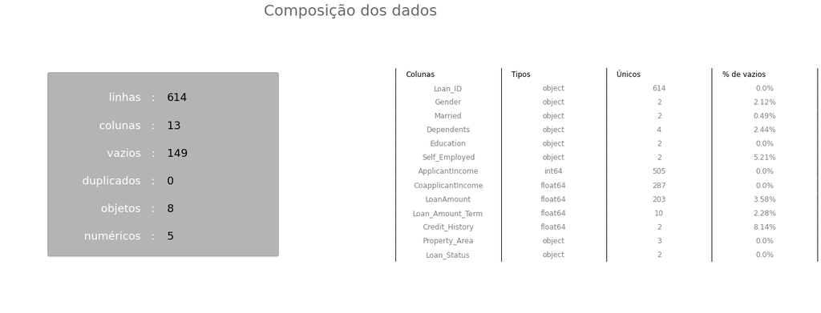

```python
vis_dados(treino)
```

```python
# Com base no gráfico acima, é importante visualizar alguns dados:
print(treino['Dependents'].unique())
print(treino['Education'].unique())
print(treino['Loan_Amount_Term'].unique())
print(treino['Property_Area'].unique())
```

```
['0' '1' '2' '3+' nan]
['Graduate' 'Not Graduate']
[360. 120. 240.  nan 180.  60. 300. 480.  36.  84.  12.]
['Urban' 'Rural' 'Semiurban']
```

```python
# Observar se há algum erro númerico:
print(treino['ApplicantIncome'].max(),treino['ApplicantIncome'].min())
print(treino['CoapplicantIncome'].max(),treino['CoapplicantIncome'].min())
print(treino['Loan_Amount_Term'].max(),treino['Loan_Amount_Term'].min())
print(treino['LoanAmount'].max(),treino['LoanAmount'].min())
```

```
81000 150
41667.0 0.0
480.0 12.0
700.0 9.0
```

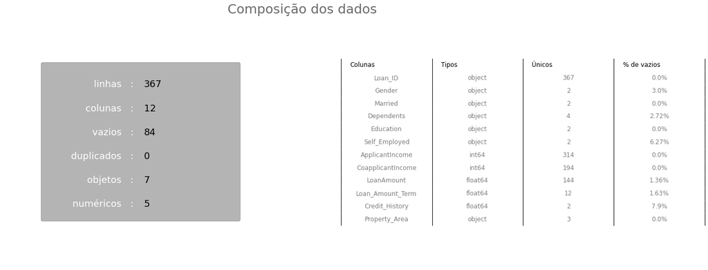

```python
vis_dados(teste)
```

## EDA e Tratamento dos dados

- O termo EDA vem do inglês: Exploratory Data Analysis, que significa Análise Exploratória dos dados, onde busca explorar de forma visual e estatística os dados para compreensão e insights presentes nesses dados, nesse processo também pode ser feito o feature engineering, que é a ação de manipular os dados para adequar aos modelos de previsão ou de estudo.
- Como foi observado na análise inicial, os dados apresentam uma quantidade de vazios, sendo mais usado duas formas de lidar com esses dados, sendo:
  - Manter os vazios como uma classificação dos dados
  - Preencher com uma medida central.
- Abaixo se encontra as funções geradas para visualização dos dados, assim como uma análise dos resultados identificados com esses gráficos.
- A análise será separada para os dados qualitativos e quantitativos e para correlações, onde será montado diversos gráficos para visualização desses dados.

### Funções

```python
def contagem(a, b,tamanho):
  """
  Função criada para ajustar ao tamanho da posição da axis, onde seria pos(a,b)
  se b for menor que o tamanho desejado -1 ele avança de linha.
  """
  if b < tamanho[1]-1:
    b+=1
    return a,b
  else:
    b=0
    a+=1
    return a,b

def barras_graf(df, titulo,tamanho):
  """
  Função criada para montar uma imagem gráfica dos gráficos de barra.
  """

  figura = plt.figure(figsize=(25,10))
  plt.suptitle(f'Dado Categórico Avaliado: {titulo}', fontsize=30, horizontalalignment='left', x=0.15 ,color='grey')
  tamanho = tamanho
  plt.subplots_adjust(top=0.8,
                      wspace = 0.5,
                      hspace = 0.5)
  a1 = 0
  b1 = 0
  for column in df:
    try:
      pos = (a1,b1) # Pos
      ax = plt.subplot2grid(tamanho, pos) # Axis
      color = '#78C' # Cor do palette

      # Para destacar Alvo
      if pos == (1,2):
        color = 'seagreen'
        ax = plt.subplot2grid(tamanho, pos, colspan=2)

  # ======= Plot

      barra = sns.barplot(orient='h',
                  x = df[column].value_counts().values,
                  y = df[column].value_counts().index,
                  palette = sns.light_palette(color) ,
                  dodge=False,
                  ax=ax,
                  order = df[column].value_counts().index)


      # Mostrar porcengatem de cada categoria.
      a = ((df[column].value_counts().values / df[column].shape[0])*100).tolist()
      b = df[column].value_counts().values.tolist()
      c = []
      for aa, bb in zip(a, b):
        c.append(f'{bb} '+ f'({aa:.2f}%)')

      # Mostrar dados no gráfico.
      co = 0
      for val, pos in zip(c, df[column].value_counts().values):
        barra.annotate(
            val,
            xy =  (pos/2, co),
            fontsize=10,
            color='black'
        )

        co+=1

      # Ajustes de configuração de axis.
      barra.set_title(f"Contagem das categorias: {column}", horizontalalignment='left', color='grey', x=0)
        # Desativar
      barra.spines['top'].set_visible(False)
      barra.spines['right'].set_visible(False)
      barra.spines['left'].set_visible(False)
        # Cor
      barra.spines['bottom'].set_color('darkgrey')
      barra.tick_params(axis='y', colors='black')
      barra.tick_params(axis='x', colors='darkgrey')

      # Atualizar Pos da axis
      a1,b1 = contagem(a1,b1,tamanho)
    except:
      pass
  return figura.show()
```

```python
def vis_num(df):
  """
  Modelo retorna um subplot dentro do subplot com o box e o histograma
  para os dados numéricos.
  """

# ========================= Configurações =========================
  fig = plt.figure(figsize=(25, 20))
  outer = gridspec.GridSpec(3, 1, wspace=0.3, hspace=0.4) # Tamanho de imagem.
  rows = 3 #Linhas
  cols = 1 #Colunas
  fig.suptitle('Análise da Distribuição dos Dados', fontsize=30, color='dimgrey') # Título da figura.

# ========================= Plotagem ==============================
  flierprops = dict(marker='x', markerfacecolor='r', markersize=4,
                  linestyle='none', markeredgecolor='darkcyan') # Ajustes de como os outliers serão mostrados.
  c = 0
  for i in range(0,rows,1): # Loop para passar por cada Coluna e Linhas.
    for j in range(cols):
      # ---------------- Plotagem do BoxPlot --------------------
      try:
        inner = gridspec.GridSpecFromSubplotSpec(2, 1,
                          subplot_spec=outer[i+j], wspace=0.1, hspace=0)  # Criando 2 espaços na posição gráfica.

        nome = quan.columns[c] # Extrair qual coluna será mostrada.
        ax = plt.Subplot(fig, inner[0]) # Axis .
        fig.add_subplot(ax) # Adicionar o axis na figura.

        box = sns.boxplot(data=df, # Plotagem Gráfica
                          orient='h',
                          x = nome,
                          ax=ax, width=.2, color='aquamarine', flierprops=flierprops)


        box.axis('off') # Desativar barras de eixo.
        box.set_title(f'{nome}',horizontalalignment='left', x=0,fontsize=18,color='dimgrey') # Título.


          # ------= Plotagem dos quantiles.
        df_temporario = df.copy()
        quantiles = df_temporario[nome].quantile([0.25, 0.75]).values.tolist() # Separação dos quantiles.
        LI = quantiles[0] - ((quantiles[1] - quantiles[0])*1.5) # Limite Inferior
        LS = quantiles[1] + ((quantiles[1] - quantiles[0])*1.5) # Limite Superior
        # Ajustes de posição do LS e LI
        if LI < df_temporario[nome].min():
          LI = df_temporario[nome].min()
        elif LI >= df_temporario[nome].min():
          LI = df_temporario.loc[df_temporario[nome] >= LI, nome].min()
        if LS > df_temporario[nome].max():
          LS = df_temporario[nome].max()
        elif LS <= df_temporario[nome].max():
          LS = df_temporario.loc[df_temporario[nome] <= LS, nome].max()

        for con, ix in enumerate([LI,LS]): # Plotar no gráfico.
          if con % 2 == 0: # Se par o plot vai a direita, se não a esquerda.
            h = 'right'
          else:
            h = 'left'
          box.annotate(round(ix,2), xy=(ix*1.01, 0.1), fontsize=11, color='rosybrown', horizontalalignment=h)
        for con, ix in enumerate(quantiles):
          mover = 0.02 # Ajuste para deslocar o texto.
          if con % 2 == 0:
            h = 'right'
            ixi = ix + (ix*-mover)
          else:
            h = 'left'
            ixi = ix + (ix*mover)
          box.annotate(round(ix,2), xy=(ixi, -0.1), fontsize=11, color='dimgrey', horizontalalignment=h, verticalalignment='bottom')
      except:
        pass

    for j in range(cols):
      # ---------------- Plotagem do Histograma -------------------
      try:
          inner = gridspec.GridSpecFromSubplotSpec(2, 1,
                            subplot_spec=outer[i+j], wspace=0.1, hspace=0) # Criando 2 espaços na posição gráfica.

          nome = quan.columns[c] # Extrair qual coluna será mostrada. # Selecionar coluna a ser trabalhada.

          ax = plt.Subplot(fig, inner[1]) # Axis.
          fig.add_subplot(ax) # Adicionar o axis na figura.

          hist = sns.histplot(data=df, x = nome,color='mediumaquamarine') # Plotagem Histograma.

          # ---------- Configurações de axis.
            # Desativar Barras de eixo.
          hist.spines['top'].set_visible(False)
          hist.spines['right'].set_visible(False)
            # Definir Cor das Barras de eixo.
          hist.spines['left'].set_color('darkgrey')
          hist.spines['bottom'].set_color('darkgrey'),
            # Parâmetros do tick.
          hist.tick_params(axis='both', colors='darkgrey')
          hist.set(xlabel='', ylabel='')



      except:
        pass
    c += 1
  return plt.show()
```

```python
def contagem(a, b,tamanho):
  """
  Função criada para ajustar ao tamanho da posição da axis, onde seria pos(a,b)
  se b for menor que o tamanho desejado -1 ele avança de linha.
  """
  if b < tamanho[1]-1:
    b+=1
    return a,b
  else:
    b=0
    a+=1
    return a,b

def corre_cat(dfe, alvo, tamanho):
  df = dfe.copy()
  colunas = df.columns.tolist()
  colunas.remove(alvo)
  figura = plt.figure(figsize=(25,14))
  figura.suptitle('Correlações categóricas com o alvo', fontsize=30, x=0.13, color='grey', horizontalalignment='left')
  tamanho = tamanho
  plt.subplots_adjust(top=0.88,
                      wspace = 0.5,
                      hspace = 0.5)
  a1 = 0
  b1 = 0
  for column in colunas:
    # try:
    pos = (a1,b1) # Pos
    ax = plt.subplot2grid(tamanho, pos) # Axis
    color = '#78C' # Cor do palette

    # Para destacar Alvo
    if pos == (1,2):
      # color = 'seagreen'
      ax = plt.subplot2grid(tamanho, pos, colspan=2)

# ======= Plot

    barra = sns.countplot(orient='h',
                          data = df,
                y = column,
                hue = alvo,
                palette = sns.light_palette(color) ,
                dodge=False,
                ax=ax,
                order = df[column].value_counts().index)


    # Mostrar porcengatem de cada categoria.
    bd0 = []
    for un in df[column].value_counts().index:
      bd = []
      total = df.loc[(df[column] == un), column].shape[0]
      for al in df[alvo].unique():
        atual = df.loc[(df[alvo] == al) & (df[column] == un), column].value_counts().values
        if atual.size <= 0:
          bd.append([0])
        else:
          bd.append(round(((atual/total)*100)[0],2))
      bd0.append(bd)
    for con, un in enumerate(bd0):
      if un[0] == 0:
        continue
      else:
        barra.annotate(
            f'{un[0]}% de  Y \n{un[1]}% de N',
            xy = (df[column].value_counts()[0]/3, con),
            horizontalalignment='center',verticalalignment='center'
        )


    # Ajustes de configuração de axis.
    barra.set_title(f"Contagem das categorias: {column}", horizontalalignment='left', color='grey', x=0)
      # Desativar
    barra.spines['top'].set_visible(False)
    barra.spines['right'].set_visible(False)
    barra.spines['left'].set_visible(False)
      # Cor
    barra.spines['bottom'].set_color('darkgrey')
    barra.tick_params(axis='y', colors='black')
    barra.tick_params(axis='x', colors='darkgrey')

    # Atualizar Pos da axis
    a1,b1 = contagem(a1,b1,tamanho)
    # except:
    #   pass
  return figura.show()
```

```python
def posicao(a, b, tamanho):
  """ Funçõa para determinar a posição de cada imagem """

  if b < tamanho[1] -1 :
    b +=1
    return a, b
  else:
    a += 1
    b = 0
    return a, b

def imagem_0(df, alvo, tamanho):
	# Configuração Inicial

  tamanho = tamanho
  figura = plt.figure(figsize=(25,15))
  a, b = 0, 0

  for ii in df.drop(alvo,axis=1):
								## Pos
    pos = (a,b)
    ax1 = plt.subplot2grid(tamanho, pos)
    a, b = posicao(a,b,tamanho)
						    ## Plot
    box = sns.boxplot(
        orient='h',
        x = df[ii],
        y = df[alvo],
        ax= ax1,
        width = 0.2,
        boxprops= {"facecolor": 'azure', "edgecolor": "grey", "linewidth": 0.5}, # Cor do box e cor das bordas do box
        whiskerprops={"color": "grey", "linewidth": 0.5}, # Cor das linhas acima e abaixo do q1 e 13
        capprops={"color": "grey", "linewidth": 0.5}, # Cor da barra limite
        medianprops={"color": "grey", "linewidth": 0.5},
        flierprops = dict(marker='+',markersize=4, markeredgecolor='red')
    )




    box.set_title(f'Gráfico : {ii}',horizontalalignment='left', x=0,fontsize=16,color='grey')

									## Conf
    for con0, elemento in enumerate(df[alvo].unique()): # Criar loop para mostrar no gráfico a posição de cada quantile.
      df_temporario = df.loc[df[alvo] == elemento] # Filtrando os dados somente contendo a classe estudada.
      nome = ii # Alvo
      quantiles = df_temporario[ii].quantile([0.25, 0.75]).values.tolist() # Separação dos quantiles.
      LI = quantiles[0] - ((quantiles[1] - quantiles[0])*1.5) # Limite Inferior
      LS = quantiles[1] + ((quantiles[1] - quantiles[0])*1.5) # Limite Superior
      # Ajustes de posição do LS e LI
      if LI < df_temporario[nome].min():
        LI = df_temporario[nome].min()
      elif LI >= df_temporario[nome].min():
        LI = df_temporario.loc[df_temporario[nome] >= LI, nome].min()
      if LS > df_temporario[nome].max():
        LS = df_temporario[nome].max()
      elif LS <= df_temporario[nome].max():
        LS = df_temporario.loc[df_temporario[nome] <= LS, nome].max()

      for con, ix in enumerate([LI,LS]): # Plotar no gráfico.
        if con % 2 == 0: # Se par o plot vai a direita, se não a esquerda.
          h = 'right'
        else:
          h = 'left'
        box.annotate(round(ix,2), xy=(ix, con0+0.2), fontsize=12, color='rosybrown', horizontalalignment=h)
      for con, ix in enumerate(quantiles):
        mover = 0.01 # Ajuste para deslocar o texto.
        if con % 2 == 0:
          h = 'right'
        else:
          h = 'left'
        box.annotate(round(ix,2), xy=(ix, con0-0.2), fontsize=12, color='dimgrey', horizontalalignment=h, verticalalignment='bottom')

        # Visualização dos eixos
      box.spines['left'].set_visible(False)
      box.spines['right'].set_visible(False)
      box.spines['top'].set_visible(False)
        # Cor
      box.spines['bottom'].set_color('darkgrey')
      box.tick_params(axis='x', colors='darkgrey')
      box.tick_params(axis='y', colors='black')
        # Ajustes
      box.set_xlabel('')
      # box.set_ylabel('')


  return figura.show()
```

### Análises

#### Qualitativos

```python
# Primeiro será separado os dados por tipo: Númerico e Categórico.
qual = treino.select_dtypes(include='object')
qual.head()
```

|  | Loan_ID | Gender | Married | Dependents | Education | Self_Employed | Property_Area | Loan_Status |
| --- | --- | --- | --- | --- | --- | --- | --- | --- |
| 0 | LP001002 | Male | No | 0 | Graduate | No | Urban | Y |
| 1 | LP001003 | Male | Yes | 1 | Graduate | No | Rural | N |
| 2 | LP001005 | Male | Yes | 0 | Graduate | Yes | Urban | Y |
| 3 | LP001006 | Male | Yes | 0 | Not Graduate | No | Urban | Y |
| 4 | LP001008 | Male | No | 0 | Graduate | No | Urban | Y |

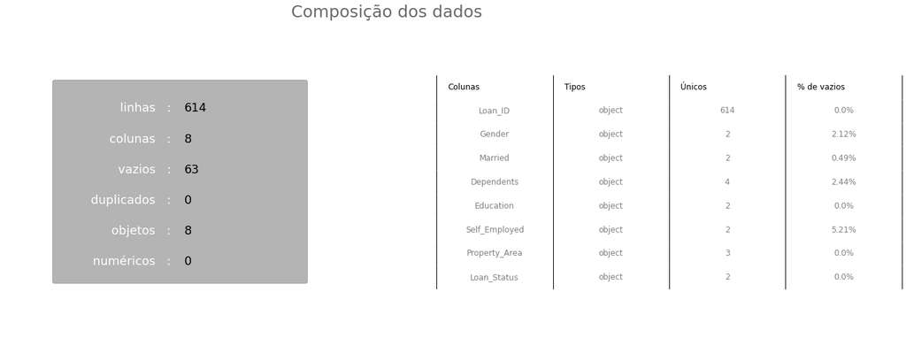

```python
vis_dados(qual)
```

```python
# Possível Perceber que 4 dos 8 dados apresentam dados vazios, então para a análise esse dados vazios serão preenchidos pela moda
for i in qual:
  if qual[i].isnull().sum() > 0:
    print(f'Dados vazios da coluna -- {i} -- serão preenchidos com : -- {qual[i].value_counts().index[0]} -- ')
    qual.loc[:,i] = qual[i].fillna(qual[i].value_counts().index[0])
```

```
Dados vazios da coluna -- Gender -- serão preenchidos com : -- Male --
Dados vazios da coluna -- Married -- serão preenchidos com : -- Yes --
Dados vazios da coluna -- Dependents -- serão preenchidos com : -- 0 --
Dados vazios da coluna -- Self_Employed -- serão preenchidos com : -- No --
```

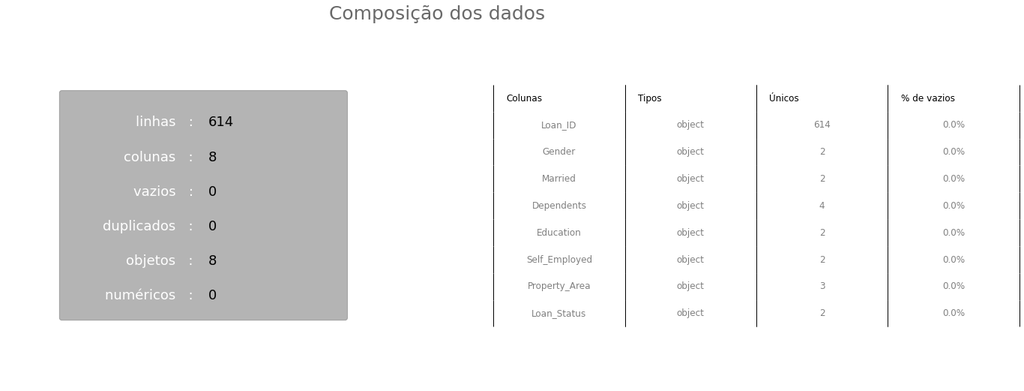

```python
vis_dados(qual)
```

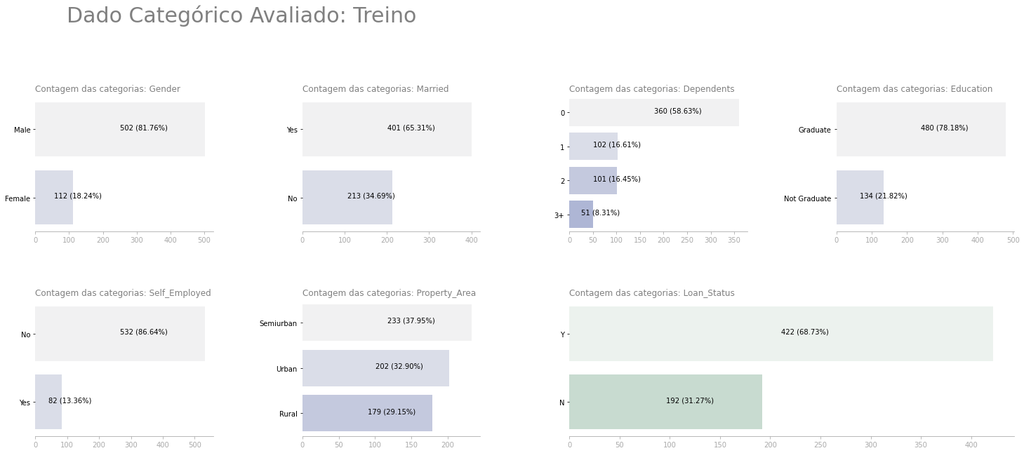

```python
barras_graf(qual.drop(['Loan_ID'],axis=1),'Treino', (2,4))
```

### Análise dados qualitativos

- Dados desbalanceados (que apresentam uma categoria com uma quantidade muito superior a outra): Self_Employed, Education e Gender. Observar a correlação desses dados com o alvo pode dar ótimos insights.
- Observando os dados que mais aparecem, têm-se Homens, Casados, sem filho, graduados, não tem o seu próprio negócio, a área mais abundante é a semi-urbana (Mas os dados são próximos) e temos que mais aprovações foram feitas do que negações.

#### Quantitativos

```python
quan = treino.select_dtypes(include=np.number)
quan.head()
```

|  | ApplicantIncome | CoapplicantIncome | LoanAmount | Loan_Amount_Term | Credit_History |
| --- | --- | --- | --- | --- | --- |
| 0 | 5849 | 0.0 | NaN | 360.0 | 1.0 |
| 1 | 4583 | 1508.0 | 128.0 | 360.0 | 1.0 |
| 2 | 3000 | 0.0 | 66.0 | 360.0 | 1.0 |
| 3 | 2583 | 2358.0 | 120.0 | 360.0 | 1.0 |
| 4 | 6000 | 0.0 | 141.0 | 360.0 | 1.0 |

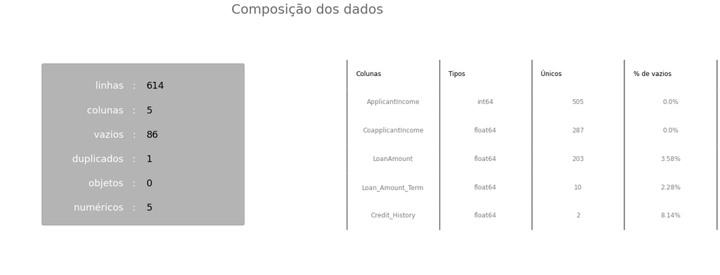

```python
vis_dados(quan)
```

- Nesse caso os dados apresentam 3 features, sendo 2 dessas features com poucos números que dá a entender que esses dados são categóricos sendo assim uma moda pode ser usada para o preenchimento dos vazios, já o outro modelo pode ser usado tanto a média como a mediana, para decidir qual modelo será usado será verificada a assimetria da distribuição do modelo, isso vai informar se essa feature não tem uma distribuição normal, ou seja, usar uma média (que é facilmente alterada com outliers) não seja a melhor escolha. Fora isso, os dados numéricos apresentam uma linha duplicada que pode ser deletada.

```python
print(quan['LoanAmount'].skew())
```

```
2.677551679256059
```

- O resultado obtido demonstra que os dados tem uma assimetria positiva, ou seja, a concentração dos dados está a esquerda. Sendo assim o modelo para o preenchimento dos dados mais adequado é a mediana.

```python
# Preencher vazios com mediana
quan.loc[:, 'LoanAmount'] = quan['LoanAmount'].fillna(quan['LoanAmount'].median())

# Preencher vazios com moda
for i in ['Loan_Amount_Term','Credit_History']:
  quan.loc[:,i] = quan[i].fillna(quan[i].value_counts().index[0])
```

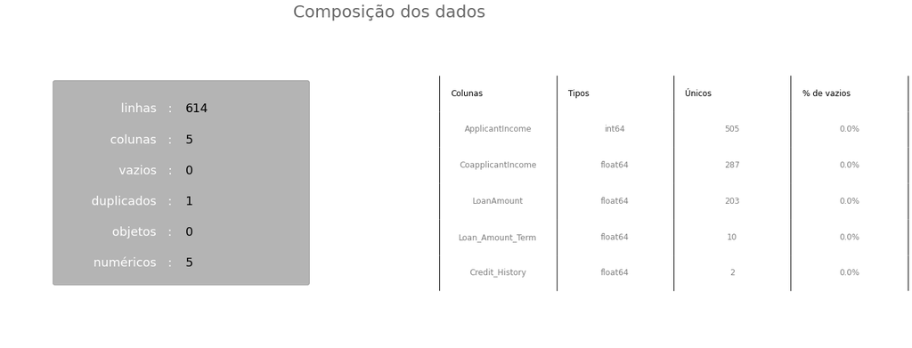

```python
vis_dados(quan)
```

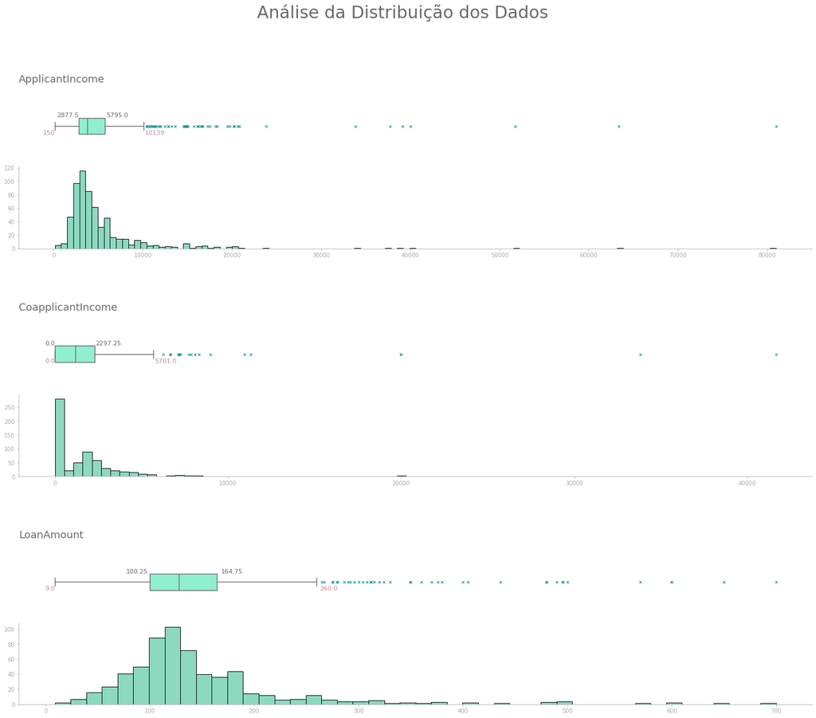

```python
vis_num(quan.iloc[:,:3])
```

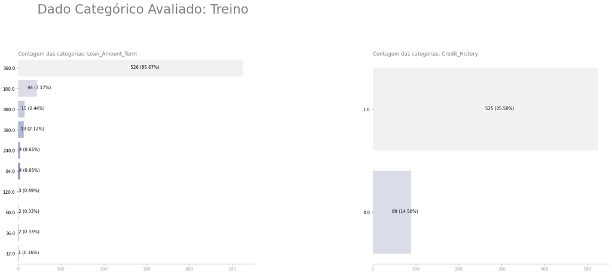

```python
barras_graf(quan.iloc[:,3:],'Treino', (1,2))
```

- 3 features são dados continuos.
- Duas dessas tem a distribuição do tipo exponencial (quando a ponta não é a barra mais alta, mas tem uma assimetria para uma das direções), sendo o outro do tipo gamma (que apresenta a ponta como o pico dos dados).
- Dados apresentam uma assimetria positiva, ou seja, podem conter viés (uma alternativa interessante pode ser a normalização dos dados para corrigir esse problema de viés)
- Já nos dados numéricos categóricos temos dois dados altamente desbalanceados, sendo um deles uma provavel alternativa de tratamento a redução de features, ou seja, manter somente as categorias relevantes, mas como outros valores podem aparecer, os dados serão mantidos como estão e o dado será tratado como um contínuos, já o histórico de crédito será tratado como categórico.

#### Correlação

```python
# Passando para o categórico.
treino['Credit_History'] = treino['Credit_History'].astype(str)
```

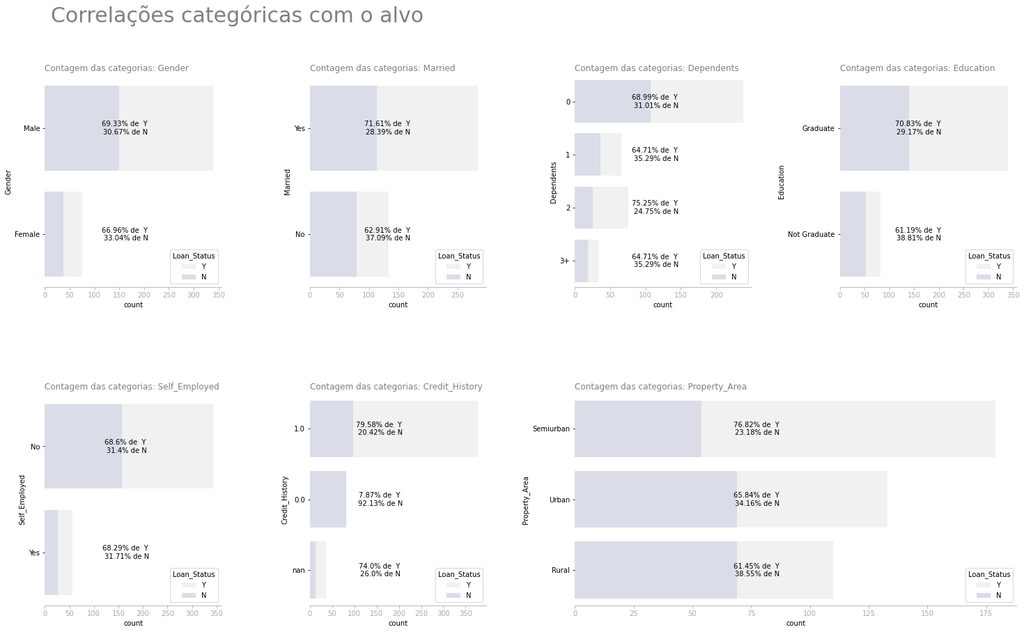

```python
corre_cat(treino.select_dtypes(include='object').drop('Loan_ID',axis=1),'Loan_Status', (2,4))
```

```python
dt1 = treino.select_dtypes(include=np.number).columns.tolist()+['Loan_Status']
dt1 = treino.loc[:,dt1]
```

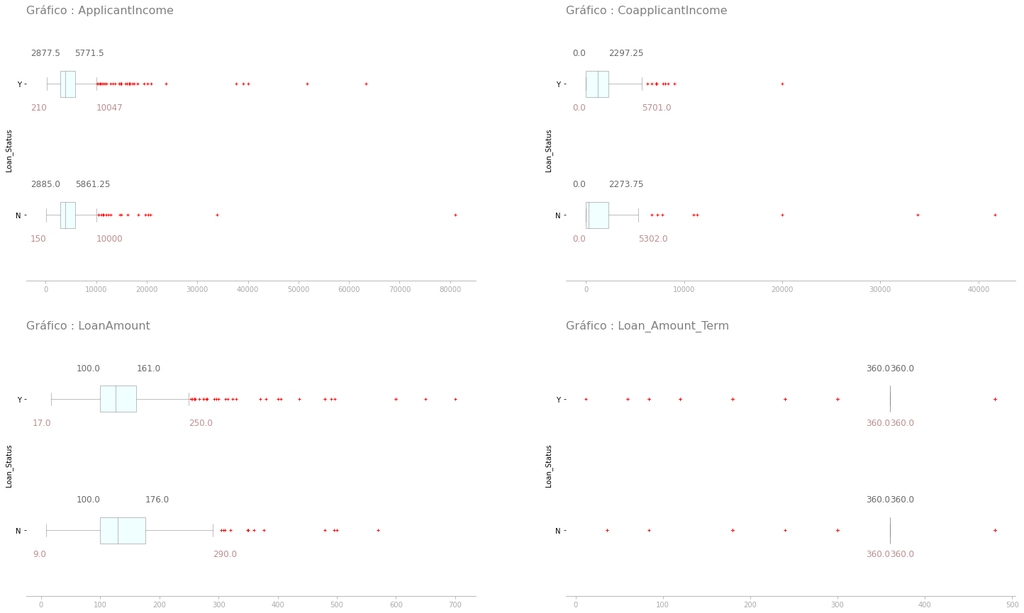

```python
imagem_0(dt1, 'Loan_Status', (2,2))
```

## Análise de correlações

- Os gráficos de barra gerados foram plotados de forma sobreposta, sendo assim podemos ver o quanto uma categoria está além da outra.
- Dê informações mais relevantes é possível concluir que o histórico de crédito é um dos grandes fatores que favorecem uma aprovação. Outro fator que parece ter um grau de relevância maior é a graduação, onde pessoas com graduação tiveram uma porcentagem maior de aprovação.
- A localização do imóvel também parece ser um fator bem relevante, onde as casas localizadas na região semi-urbana tem uma taxa maior de aprovação. É relevante também observar que se a pessoa é casada há uma taxa maior de aprovação. Fora essas observações, os outros dados apresentaram uma distribuição semelhante.
- Para os dados numéricos o gráfico demonstra que todos tendem a ter uma distribuição bem idêntica.

# Modelo de Machine Learning

### Etapas

- Tratamento dos dados
  - Feito a junção dos dados de treino e teste
  - Preenchimento dos vazios
  - Encoder
  - normalização dos dados
  - padronização dos dados
  - Balanceamento dos dados

Será criado uma função para definir quais modificações podem ser feitas nos dados, isso facilita no momento dos testes dos dados, onde diferentes tratamentos podem apresentar bons resultados.

- Modelos de Machine Learning
  - Árvore de decisão
    - RandomForest
    - Gradient Boost
    - Adamboost
    - Lightgbm
  - SVM
  - KNN
  - Bayesian
- Modelos de avaliação
  - roc_auc
  - f1_score
- Hiperparâmetro do melhor modelo

## Funções

```python
def tratamento(encoder=0, padro=0, norm = 0):

  treino_novo = treino.copy() # Cópia do treino
  lb = LabelEncoder()
  treino_novo.loc[:,'Loan_Status'] = lb.fit_transform(treino_novo['Loan_Status'])
  alvo = treino_novo.pop('Loan_Status') # Separação da previsão
  teste_novo = teste.copy() # Cópia de teste
  tratar = pd.concat([treino_novo, teste_novo], axis=0) # Junção dos dados
  id = tratar.pop('Loan_ID') # Remoção do Id
  texto = ''
# ======================================================= Preencher Vazios ============

  # ------  $  Categóricos

  cat = tratar.select_dtypes(include='object')

  for i in cat:
    if cat[i].isnull().sum() > 0:
      moda = cat[i].value_counts().index[0]
      tratar.loc[:,i] = tratar[i].fillna(moda)

  # ------  $  Numéricos

  num = tratar.select_dtypes(include=np.number)
  for i in num:
          # Moda
    if num[i].nunique() < 20:
      moda = num[i].value_counts().index[0]
      tratar.loc[:,i] = tratar[i].fillna(moda)
          # Mediana
    else:
      mediana = num[i].median()
      tratar.loc[:,i] = tratar[i].fillna(mediana)

# ================================================================ Encoder ============

  # ------  $  Label Encoder
  if encoder == 0:
    for enc in cat:
      tratar.loc[:,enc] = LabelEncoder().fit_transform(cat[enc].astype(str))
    texto = texto + 'Label Encoder '
  # ------  $ One Hot Encoder
  elif encoder == 1:
    tratar = pd.get_dummies(tratar, columns=cat.columns, drop_first=True)
    texto = texto + 'Dummies '
  # ------  $ Frequency Encoding
  elif encoder == 2:
    for i in cat:
      valores = cat[i].value_counts()/len(cat[i])
      tratar.loc[:,i] = tratar[i].map(valores)
    texto = texto + 'Frequency Encoder '
# ================================================== Normalização Gausseana =========
  if norm == 1:
    for i in num:
      if num[i].nunique() > 20:
        tratar.loc[:,i] = np.log(tratar[i].values + 1)
    texto = texto + '/Normalização '

# ===================================================== Padronização dos dados ========

 # ------  $  Padronização
  if padro == 0:
    pass
  elif padro == 1:
    std = StandardScaler()
    tratar.iloc[:,:] = std.fit_transform(tratar)
    texto = texto + '/Standard Scaler '
  elif padro == 2:
    mms = MinMaxScaler()
    tratar.iloc[:,:] = mms.fit_transform(tratar)
    texto = texto + '/Min Max Scaler '
  else:
    pass

# ===================================== Separação dos dados e junção com alvo ========
  train = tratar.iloc[treino.shape[0]:,:]
  test = tratar.iloc[:treino.shape[0],:]
  train['Loan_Status'] = alvo


  return train, test, texto
```

```python
def balanceamento(df,alvo, entrada=0):
  """

  """
# ================== Sem Balanceamento.
  if entrada == 0:
    return df, alvo

# ================== Under Sampling a classe majoritária.
  elif entrada == 1:
    df['Loan_Status'] = alvo
    count_y, count_n = df['Loan_Status'].value_counts()

    df_class_y = df[df['Loan_Status'] == 1]
    df_class_n = df[df['Loan_Status'] == 0]

    under_class_y = df_class_y.sample(count_n)

    df = pd.concat([under_class_y, df_class_n], axis=0)
    df = df.reset_index(drop=True)
    alvo = df.pop('Loan_Status')
    return df, alvo

# ================== Under Sampling com Tomek Link.
  elif entrada == 2:
    tl = TomekLinks()
    X_bal, y_bal = tl.fit_resample(df, alvo)
    return X_bal, y_bal

# ================== Over Sampling duplicando classe minoritária.
  elif entrada == 3:
    df['Loan_Status'] = alvo
    count_y, count_n = df['Loan_Status'].value_counts()

    df_class_y = df[df['Loan_Status'] == 1]
    df_class_n = df[df['Loan_Status'] == 0]

    over_class_n = df_class_n.sample(count_y, replace=True)

    df = pd.concat([df_class_y, over_class_n], axis=0)
    df = df.reset_index(drop=True)
    alvo = df.pop('Loan_Status')
    return df, alvo

# ================== Over Sampling usando SMOTE.
  elif entrada == 4:
    smote = SMOTE(sampling_strategy = 'minority')
    X_bal, y_bal = smote.fit_resample(df, alvo)
    return X_bal, y_bal
```

```python
def box(df, titulo, ax):
  box = sns.boxplot(data= df, x = 'F1', y='Modelo', width=0.2, palette = 'YlOrBr',ax=ax,
                    whiskerprops={"color": "lightgrey", "linewidth": 0.5}, # Cor das linhas acima e abaixo do q1 e 13
                    capprops={"color": "lightgrey", "linewidth": 0.5}, # Cor da barra limite
                    flierprops = dict(marker='+',markersize=6, markeredgecolor='red'),
                    boxprops= {"edgecolor": "lightgrey", "linewidth": 0.5}
                    )
  for con0, elemento in enumerate(df['Modelo'].unique()): # Criar loop para mostrar no gráfico a posição de cada quantile.
    df_temporario = df.loc[df['Modelo'] == elemento] # Filtrando os dados somente contendo a classe estudada.
    nome = 'F1' # Alvo
    quantiles = df_temporario[nome].quantile([0.25, 0.75]).values.tolist() # Separação dos quantiles.
    LI = quantiles[0] - ((quantiles[1] - quantiles[0])*1.5) # Limite Inferior
    LS = quantiles[1] + ((quantiles[1] - quantiles[0])*1.5) # Limite Superior
    # Ajustes de posição do LS e LI
    if LI < df_temporario[nome].min():
      LI = df_temporario[nome].min()
    elif LI >= df_temporario[nome].min():
      LI = df_temporario.loc[df_temporario[nome] >= LI, nome].min()
    if LS > df_temporario[nome].max():
      LS = df_temporario[nome].max()
    elif LS <= df_temporario[nome].max():
      LS = df_temporario.loc[df_temporario[nome] <= LS, nome].max()

    for con, ix in enumerate([LI,LS]): # Plotar no gráfico.
      if con % 2 == 0: # Se par o plot vai a direita, se não a esquerda.
        h = 'right'
      else:
        h = 'left'
      box.annotate(round(ix,3), xy=(ix, con0+0.1), fontsize=12, color='black', horizontalalignment=h)
    for con, ix in enumerate(quantiles):
      mover = 0.01 # Ajuste para deslocar o texto.
      if con % 2 == 0:
        h = 'right'
      else:
        h = 'left'
      box.annotate(round(ix,3), xy=(ix, con0-0.1), fontsize=12, color='black', horizontalalignment=h, verticalalignment='bottom')

    # ------  Configurações Eixo
          # Desativar.
  box.spines['top'].set_visible(False)
  box.spines['right'].set_visible(False),
  box.spines['left'].set_visible(False),
    # Cor.
  box.spines['bottom'].set_color('darkgrey')
  box.tick_params(axis='x', colors='darkgrey')
  box.tick_params(axis='y', colors='black')
    # Ajustes
  box.set_xlim([df['F1'].min()*0.8,df['F1'].max()*1.1 ])
  box.set_xlabel('')
  box.set_ylabel('')
  box.set_title(f'{titulo}',horizontalalignment='center', fontsize=16,color='grey');

# ADICIONAR TEMPO DE RODAGEM DE CADA UM DOS MODELOS.
```

```python
def modelos_ml(X_treino, X_teste, y_treino, y_teste, resultados):

  modelos = {
      'Logistic':LogisticRegression(max_iter=300),
      'Gaussian':GaussianNB(),
      'random forest':RandomForestClassifier(n_estimators=300),
      'Gradient B.':GradientBoostingClassifier(n_estimators=300),
      'Ada B.':AdaBoostClassifier(n_estimators=300),
      'Light':LGBMClassifier(n_estimators=300),
      'SVC':SVC(cache_size=300),
      'KNN':KNeighborsClassifier(n_neighbors=10)
  }
  grafico = []
  results = [y_teste]
  for classificador in modelos:
    # print(f'Modelo em rodage : {classificador}')
    model = modelos[classificador].fit(X_treino, y_treino)
    predict = model.predict(X_teste)
    resultados.append([classificador, f1_score(y_teste, predict), roc_auc_score(y_teste, predict)])

  time.sleep(3)
  return resultados
```

```python
def contagem(a, b,tamanho):
  """
  Função criada para ajustar ao tamanho da posição da axis, onde seria pos(a,b)
  se b for menor que o tamanho desejado -1 ele avança de linha.
  """
  if b < tamanho[1]-1:
    b+=1
    return a,b
  else:
    b=0
    a+=1
    return a,b



def analise_resultado(balance=0):
  # Criação da imagem
  dict_results = {}
  c = 18
  skf = StratifiedKFold(n_splits=5) # Separação dos dados
  for k in range(2):
    for i in range(3):
      for j in range(3):
        print(f'Faltando {c} rodadas')
        c -= 1
        resultados = []
        treino_tratado , test_tratado, texto = tratamento(i,j,k)
        for train_index, test_index in skf.split(treino_tratado.drop('Loan_Status',axis=1), treino_tratado['Loan_Status']):

          y_tratado = treino_tratado['Loan_Status']

          X_tr = treino_tratado.iloc[train_index, :].drop('Loan_Status', axis=1)
          X_te = treino_tratado.iloc[test_index, :].drop('Loan_Status', axis=1)
          y_tr = y_tratado.iloc[train_index]
          y_te = y_tratado.iloc[test_index]

          X_tr, y_tr = balanceamento(X_tr, y_tr, balance)
          resultados = modelos_ml(X_tr, X_te, y_tr, y_te, resultados)


        grafico = pd.DataFrame(resultados, columns=['Modelo','F1','ROC']).sort_values(by='F1',ascending=False).reset_index(drop=True).dropna()

        dict_results.update({texto:grafico})
  return dict_results
```

```python
def analise_grafica(dc,titulo):
  a = 0
  b = 0
  figura = plt.figure(figsize=(20,10))
  tamanho = (1,2)
  plt.subplots_adjust(left=0, #AJUSTES
                    bottom=0,
                    right=0.9,
                    top=0.85,
                    hspace=0.2,
                    wspace=0.35)
  figura.suptitle(f'Análise de resultados {titulo}', fontsize=45, horizontalalignment='center', x=0.45)
  for i in dc:
    dte = dc[i]
    df = dte.copy()
    df['F1'] = (df['F1'] * 100).round(2)
    pos = (a,b)
    ax = plt.subplot2grid(tamanho, pos)
    box(df,i, ax)
    a, b = contagem(a, b, tamanho)
```